# Main

Estes dados são referentes a venda de apartamentos na cidade de Curitiba, disponibilizado dentro da plataforma do kaggle conforme o link abaixo. As informações contidas nele são de características dos apartamentos, como quantidade de vagas de garagem, quantidade de quartos e quantidade de banheiros, bem como informações sobre a localidade e valores referente as despesas fixas e valor monetário para a aquisição. Pelo apresentado os dados parecem ter sido retirados em uma data especifica, possivelmente próximo da sua disponibilização, setembro 2022. O principal obtivo ao analisar os dados é de entender como esta o panorama do valores dos apartamento dentro da cidade de Curitiba, se existe e como são relacionados as características dos apartamento e localidades com os valores apresentados. https://www.kaggle.com/datasets/wittmannf/curitiba-apartment-prices

```python
import pandas as pd
import matplotlib.pyplot as plt
import seaborn as sns
import numpy as np
```

```python
from sklearn.linear_model import LinearRegression
from sklearn.model_selection import cross_val_score
import statsmodels.api as sm
from scipy import stats
from statsmodels.tools.tools import add_constant
from statsmodels.stats.outliers_influence import variance_inflation_factor
from sklearn.preprocessing import scale
```

Importando os dados

```python
df = pd.read_csv("curitiba_apartment_real_estate_data.csv")
```

```python
colunas = dict({'usableAreas': "Area_privativa", 'totalAreas': "Area_total", 'bathrooms': "Banheiros", 'bedrooms': "Quartos",
       'parkingSpaces': "Vagas_carro", 'amenities': "Facilidades", 'description':"Descricao", 'title': "Titulo", 'zipCode':"CEP",
       'street': "Rua", 'neighborhood': "Bairro", 'yearlyIptu': "IPTU", 'monthlyCondoFee': "Valor_condominio",
       'price': "Preco", 'suites':"Suites"})

df = df.rename(columns=colunas)
```

```python
df.head(3)
```

|  | Area_privativa | Area_total | Suites | Banheiros | Quartos | Vagas_carro | Facilidades | Descricao | Titulo | CEP | lon | lat | Rua | Bairro | poisList | IPTU | Valor_condominio | Preco |
| --- | --- | --- | --- | --- | --- | --- | --- | --- | --- | --- | --- | --- | --- | --- | --- | --- | --- | --- |
| 0 | 77 | 90.0 | 1.0 | 2 | 3 | 1.0 | ['BARBECUE_GRILL', 'ELEVATOR', 'GATED_COMMUNIT... | Apartamento com 3 dormitórios, sendo uma suíte... | Apartamento para venda tem 77 metros quadrados... | 82540130 | -49.249319 | -25.394261 | Rua Nossa Senhora de Nazaré | Boa Vista | ['BS:Estação Tubo Holanda', 'BS:Estação-tubo G... | 700.0 | 400.0 | 595000 |
| 1 | 53 | 53.0 | NaN | 1 | 3 | 1.0 | ['BARBECUE_GRILL', 'GATED_COMMUNITY', 'GYM', '... | Apartamento ensolarado e com linda vista pro P... | Apartamento ensolarado com 3 quartos ao lado d... | 81320180 | -49.326716 | -25.474533 | Rua Alfredo José Pinto | Fazendinha | ['BS:Rua José Gonçalves Júnior, 182', 'BS:Rua ... | NaN | 392.0 | 185000 |
| 2 | 113 | NaN | 1.0 | 4 | 3 | 2.0 | ['POOL', 'BARBECUE_GRILL', 'ELEVATOR', 'GATED_... | 22º andar, face Norte, linda vista para a Serr... | Apt para venda no Cond. Botânica: 113 m² com 3... | 80050470 | -49.239110 | -25.437162 | Rua Coronel Pedro Scherer Sobrinho | Cristo Rei | ['BS:Estação Hospital Cajuru', 'BS:Linha Turis... | 240.0 | 550.0 | 1220000 |

Verificando o tamanho e características do dataset

```python
df.shape
```

```
(18760, 18)
```

```python
df.info()
```

```
<class 'pandas.core.frame.DataFrame'>
RangeIndex: 18760 entries, 0 to 18759
Data columns (total 18 columns):
 #   Column            Non-Null Count  Dtype
---  ------            --------------  -----
 0   Area_privativa    18760 non-null  int64
 1   Area_total        18030 non-null  float64
 2   Suites            17456 non-null  float64
 3   Banheiros         18760 non-null  int64
 4   Quartos           18760 non-null  int64
 5   Vagas_carro       18097 non-null  float64
 6   Facilidades       18760 non-null  object
 7   Descricao         18730 non-null  object
 8   Titulo            18633 non-null  object
 9   CEP               18760 non-null  int64
 10  lon               13195 non-null  float64
 11  lat               13195 non-null  float64
 12  Rua               15689 non-null  object
 13  Bairro            18760 non-null  object
 14  poisList          18760 non-null  object
 15  IPTU              14412 non-null  float64
 16  Valor_condominio  15169 non-null  float64
 17  Preco             18760 non-null  int64
dtypes: float64(7), int64(5), object(6)
memory usage: 2.6+ MB
```

Iniciando o processo de limpeza, primeiro retirando as colunas de "latitude" e "longitude" e preenchendo os valores de "suites" que estão como NaN com o valor 0

```python
df_limpo = df.drop(["lon","lat"],axis=1).copy()
df_limpo["Suites"] = df_limpo["Suites"].fillna(0)
df_limpo[df.isna().any(axis=1)].head(4)
```

|  | Area_privativa | Area_total | Suites | Banheiros | Quartos | Vagas_carro | Facilidades | Descricao | Titulo | CEP | Rua | Bairro | poisList | IPTU | Valor_condominio | Preco |
| --- | --- | --- | --- | --- | --- | --- | --- | --- | --- | --- | --- | --- | --- | --- | --- | --- |
| 1 | 53 | 53.0 | 0.0 | 1 | 3 | 1.0 | ['BARBECUE_GRILL', 'GATED_COMMUNITY', 'GYM', '... | Apartamento ensolarado e com linda vista pro P... | Apartamento ensolarado com 3 quartos ao lado d... | 81320180 | Rua Alfredo José Pinto | Fazendinha | ['BS:Rua José Gonçalves Júnior, 182', 'BS:Rua ... | NaN | 392.0 | 185000 |
| 2 | 113 | NaN | 1.0 | 4 | 3 | 2.0 | ['POOL', 'BARBECUE_GRILL', 'ELEVATOR', 'GATED_... | 22º andar, face Norte, linda vista para a Serr... | Apt para venda no Cond. Botânica: 113 m² com 3... | 80050470 | Rua Coronel Pedro Scherer Sobrinho | Cristo Rei | ['BS:Estação Hospital Cajuru', 'BS:Linha Turis... | 240.0 | 550.0 | 1220000 |
| 4 | 66 | NaN | 1.0 | 2 | 3 | 1.0 | ['BARBECUE_GRILL', 'GATED_COMMUNITY', 'PETS_AL... | Excelente apto garden com 66m² de área útil em... | Apartamento Novo Mundo 66m² útil | 81050150 | Rua Deputado Waldemiro Pedroso | Novo Mundo | ['BS:Ponto - 672 Formosa', 'BS:Ponto - 615 Ube... | NaN | NaN | 269990 |
| 5 | 57 | 70.0 | 0.0 | 1 | 3 | 1.0 | ['GATED_COMMUNITY', 'PETS_ALLOWED', 'GARDEN', ... | Apartamento no Santa Quitéria. Direto com o pr... | Apartamento Impecável - totalmente reformado | 80330180 | Rua Rezala Simão | Santa Quitéria | ['BS:Rua José Gonçalves Júnior, 182', 'BS:Rua ... | 400.0 | 500.0 | 230000 |

No próximo passo, estão sendo corridos alguns valores que foram identificados como outliers na análise exploratória de dados, provavelmente por algum erro na aquisição dos dados

```python
indice_atuba = df_limpo["Bairro"].str.contains("Atuba") & ( df_limpo["Preco"] > 10000000)
df_limpo.loc[indice_atuba,"Preco"] = df_limpo.loc[indice_atuba,"Preco"]/100

indice_agua_verde = df_limpo["Bairro"].str.contains("Água Verde") & ( df_limpo["Preco"] > 20000000)
df_limpo.loc[indice_agua_verde,"Preco"] = df_limpo.loc[indice_agua_verde,"Preco"]/100
df_limpo[indice_agua_verde]

indice_iptu = (df_limpo["IPTU"] / df_limpo["Preco"]) > 0.02
df_limpo = df_limpo.loc[~indice_iptu,:]

indice_pilarzinho = df_limpo["Bairro"].str.contains("Pilarzinho") & ( df_limpo["Valor_condominio"] > 1000)
df_limpo.loc[indice_pilarzinho,"Valor_condominio"] = df_limpo.loc[indice_pilarzinho,"Valor_condominio"]/1000

indice_condominios = ((df_limpo["Valor_condominio"]/df_limpo["Preco"])> 0.01)
df_limpo.loc[indice_condominios,"Valor_condominio"] = df_limpo.loc[indice_condominios,"Valor_condominio"]/1000

indice_tuiuti = df_limpo["Bairro"].str.contains("Tuiuti")
df_limpo = df_limpo.loc[~indice_tuiuti,:]

indice_preco = (df_limpo["Preco"] > 100000000)
df_limpo = df_limpo.loc[~indice_preco,:]
```

Em seguida é gerado um novo Dataframe com as informações dos CEPs e das Ruas com o objetivo de preencher os valores vazios da coluna "street". Embora o CEP possa ser obtido através de uma base de dados externa e não estar necessariamente vinculado a uma rua foi optado por esse método para explorar as formas de trabalho com o Pandas

```python
lista_cep = df[["CEP","Rua"]]
lista_cep = lista_cep.groupby(["CEP","Rua"]).size().reset_index().drop(columns=0)
lista_cep.nunique()["CEP"] == len(lista_cep)
```

```
True
```

```python
mapping = dict(zip(lista_cep["CEP"],lista_cep["Rua"]))
[print(x,":",mapping[x]) for x in list(mapping)[1:10]]
```

```
80010010 : Rua Marechal Deodoro
80010020 : Rua Pedro Ivo
80010030 : Praça Rui Barbosa
80010050 : Rua Emiliano Perneta
80010060 : Travessa Jesuíno Marcondes
80010070 : Rua Senador Alencar Guimarães
80010080 : Rua André de Barros
80010090 : Travessa Frei Caneca
80010100 : Avenida Visconde de Guarapuava
```

```
[None, None, None, None, None, None, None, None, None]
```

Utilizando as informações dos CEPs e das Ruas como um dicionário, foi então criada uma nova coluna (Temporária) com as mesmas informações do CEPs e então utilizado o comando replace() para então transforma-los em nomes de Ruas. Em seguida os espaços em branco foram preenchidos e a coluna que tinha sido criada, foi deletada

```python
df_limpo["Rua_2"] = df_limpo["CEP"]
df_limpo["Rua_2"] = df_limpo["Rua_2"].replace(mapping)
df_limpo["Rua"] = df_limpo["Rua"].fillna(df_limpo["Rua_2"])
df_limpo = df_limpo.drop("Rua_2",axis=1)

sum(df_limpo["Rua"].isna())
```

```
0
```

Nessa próxima etapa foi verificado que alguns itens continham a área privativa maior do que a área total

```python
df_limpo[df_limpo["Area_privativa"] > df_limpo["Area_total"]][["Area_privativa","Area_total"]]
```

|  | Area_privativa | Area_total |
| --- | --- | --- |
| 15 | 213 | 186.0 |
| 60 | 107 | 79.0 |
| 489 | 45 | 39.0 |
| 576 | 113 | 10.0 |
| 658 | 180 | 10.0 |
| ... | ... | ... |
| 18741 | 132 | 10.0 |
| 18742 | 132 | 10.0 |
| 18743 | 47 | 10.0 |
| 18745 | 63 | 10.0 |
| 18754 | 132 | 10.0 |

333 rows × 2 columns

Em alguns casos, parece que foi inserido um valor 10.0, não fazendo muito sentido. No lugar deles, foi colocado um valor igual a área privativas. Ao realizar uma etapa mais para frente do trabalho, percebeu-se que tinha algumas áreas muito altas, nesse caso limitou-se que para apartamento com área total acima de 1000m², aqueles que tem área privativa menor de 50% da área total estão sendo desconsiderados.

```python
df_limpo.loc[df_limpo["Area_total"] == 10, "Area_total"] = df_limpo.loc[df_limpo["Area_total"] == 10, "Area_privativa"]
df_limpo = df_limpo[~((df_limpo["Area_total"]>1000) & (df_limpo["Area_privativa"]<df_limpo["Area_total"]*1/2))]
```

Nos casos em que os valores pareciam estar invertidos (área privativas > área total) foi alterado para o que faz mais sentido (área privativas < área total)

```python
var_usableAreas = df_limpo[df_limpo["Area_privativa"] > df_limpo["Area_total"]]["Area_total"]
var_totalAreas = df_limpo[df_limpo["Area_privativa"] > df_limpo["Area_total"]]["Area_privativa"]
indice = df_limpo["Area_privativa"] > df_limpo["Area_total"]

df_limpo.loc[indice,"Area_privativa"] = var_usableAreas
df_limpo.loc[indice,"Area_total"] = var_totalAreas

sum(df_limpo["Area_privativa"] > df_limpo["Area_total"])
```

```
0
```

Os casos em que a área total possuia valores NaN foram preenchidos com o valor das áreas privativas. No caso das vagas de garagem, os valores NaN foram preenchidos com o valor 0

```python
indice = df_limpo["Area_total"].isna()
df_limpo.loc[indice,"Area_total"] = df_limpo.loc[indice,"Area_privativa"]
df_limpo["Vagas_carro"] = df_limpo["Vagas_carro"].fillna(0)
```

A próxima etapa foi o IPTU, foram estimadas as medias atraves das divisões fornecidas no site da prefeitura.

```python
df_limpo = df_limpo[df_limpo["Preco"]> 67710]
df_limpo.loc[df_limpo["IPTU"] == 0,"IPTU"] = None
df_limpo["Aliquota"] = df_limpo["IPTU"]/df_limpo["Preco"]

def Classificacao_IPTU(x):
    if (x > 67710) and (x <= 87036): return "Classe_0"
    if (x > 87036) and (x <= 125685): return "Classe_1"
    if (x > 125685) and (x <= 183659): return "Classe_2"
    if (x > 183659) and (x <= 241632): return "Classe_3"
    if (x > 241632) and (x <= 299606): return "Classe_4"
    if (x > 299606): return "Classe_5"
    if x.isna(): return NA

df_limpo["IPTU_cat"] = df_limpo["Preco"].apply(Classificacao_IPTU)
df_limpo

media_aliquota = df_limpo.groupby("IPTU_cat")["Aliquota"].mean()
media_aliquota_dict = dict(media_aliquota)
media_aliquota_dict
```

```
{'Classe_0': nan,
 'Classe_1': 0.0011350276745760593,
 'Classe_2': 0.0011845338319475393,
 'Classe_3': 0.0011718417853700657,
 'Classe_4': 0.0008582834405239207,
 'Classe_5': 0.0010011513291393005}
```

```python
df_limpo["Media_iptu"] = df_limpo["IPTU_cat"].replace(media_aliquota_dict)*df_limpo["Preco"]
df_limpo["IPTU"] = df_limpo["IPTU"].fillna(df_limpo["Media_iptu"])
df_limpo.head(3)
```

|  | Area_privativa | Area_total | Suites | Banheiros | Quartos | Vagas_carro | Facilidades | Descricao | Titulo | CEP | Rua | Bairro | poisList | IPTU | Valor_condominio | Preco | Aliquota | IPTU_cat | Media_iptu |
| --- | --- | --- | --- | --- | --- | --- | --- | --- | --- | --- | --- | --- | --- | --- | --- | --- | --- | --- | --- |
| 0 | 77 | 90.0 | 1.0 | 2 | 3 | 1.0 | ['BARBECUE_GRILL', 'ELEVATOR', 'GATED_COMMUNIT... | Apartamento com 3 dormitórios, sendo uma suíte... | Apartamento para venda tem 77 metros quadrados... | 82540130 | Rua Nossa Senhora de Nazaré | Boa Vista | ['BS:Estação Tubo Holanda', 'BS:Estação-tubo G... | 700.00000 | 400.0 | 595000.0 | 0.001176 | Classe_5 | 595.685041 |
| 1 | 53 | 53.0 | 0.0 | 1 | 3 | 1.0 | ['BARBECUE_GRILL', 'GATED_COMMUNITY', 'GYM', '... | Apartamento ensolarado e com linda vista pro P... | Apartamento ensolarado com 3 quartos ao lado d... | 81320180 | Rua Alfredo José Pinto | Fazendinha | ['BS:Rua José Gonçalves Júnior, 182', 'BS:Rua ... | 216.79073 | 392.0 | 185000.0 | NaN | Classe_3 | 216.790730 |
| 2 | 113 | 113.0 | 1.0 | 4 | 3 | 2.0 | ['POOL', 'BARBECUE_GRILL', 'ELEVATOR', 'GATED_... | 22º andar, face Norte, linda vista para a Serr... | Apt para venda no Cond. Botânica: 113 m² com 3... | 80050470 | Rua Coronel Pedro Scherer Sobrinho | Cristo Rei | ['BS:Estação Hospital Cajuru', 'BS:Linha Turis... | 240.00000 | 550.0 | 1220000.0 | 0.000197 | Classe_5 | 1221.404622 |

Com relação aos dados de condomínio que estavam faltando, optou-se por preenche-los com a média do valores de condomínio por bairro, mais a frente isso foi mudado para uma regressão linear

```python
data_condominio = df_limpo.groupby("Bairro")["Valor_condominio"].mean().fillna(0)
data_condominio_dict = dict(data_condominio)
[print(x,":",data_condominio_dict[x]) for x in list(data_condominio_dict)[1:10]]
```

```
Ahú : 768.1073434343434
Alto Boqueirão : 238.62962962962962
Alto da Glória : 653.6551724137931
Alto da Rua XV : 608.9772727272727
Atuba : 285.0
Augusta : 226.0
Bacacheri : 355.21471604938273
Bairro Alto : 210.66666666666666
Barreirinha : 268.0
```

```
[None, None, None, None, None, None, None, None, None]
```

Depois como ainda tinha alguns dados em branco, optou-se por deleta-los, bem como deletar os bairros que tinham sido adicionados com o IPTU igual a 0

```python
df_limpo = df_limpo[~df_limpo[["Descricao","Titulo","Media_iptu","IPTU"]].isna().any(axis=1)]
df_limpo = df_limpo[df_limpo["IPTU"] != 0]
```

```python
NA_condominio = df_limpo["Valor_condominio"].isna() | df_limpo["Valor_condominio"].eq(0)
df_limpo["Valor_condominio"] = df_limpo["Valor_condominio"].fillna(df_limpo["Bairro"]).replace(data_condominio_dict)
df_limpo["Valor_por_metro_quadrado"] = df_limpo["Preco"]/df_limpo["Area_privativa"]
```

No final sobrou 18440 linhas das 18760 que tinha nos dados iniciais

```python
df_limpo.shape
```

```
(18440, 20)
```

```python
colunas = ['Area_privativa', 'Area_total', 'Suites', 'Banheiros', 'Quartos',
       'Vagas_carro', 'IPTU', 'Valor_condominio', 'Preco',
       'Media_iptu','Valor_por_metro_quadrado']

medias_bairros = df_limpo.groupby("Bairro")[colunas].mean().sort_values("Preco")
medias_bairros
```

| Bairro | Area_privativa | Area_total | Suites | Banheiros | Quartos | Vagas_carro | IPTU | Valor_condominio | Preco | Media_iptu | Valor_por_metro_quadrado |
| --- | --- | --- | --- | --- | --- | --- | --- | --- | --- | --- | --- |
| Campo de Santana | 45.400000 | 48.900000 | 0.000000 | 1.000000 | 2.000000 | 0.950000 | 179.723400 | 247.750000 | 1.346850e+05 | 157.230220 | 2990.834254 |
| Ganchinho | 43.000000 | 48.000000 | 0.000000 | 1.000000 | 2.000000 | 1.000000 | 165.834736 | 280.000000 | 1.400000e+05 | 165.834736 | 3255.813953 |
| Tatuquara | 45.740741 | 49.222222 | 0.000000 | 1.000000 | 2.000000 | 0.888889 | 161.530800 | 189.782609 | 1.446696e+05 | 170.030075 | 3189.320272 |
| Cachoeira | 45.250000 | 67.000000 | 0.000000 | 1.000000 | 2.000000 | 1.000000 | 147.675047 | 177.875000 | 1.516250e+05 | 179.287641 | 3370.598451 |
| Augusta | 49.200000 | 52.800000 | 0.000000 | 1.000000 | 2.000000 | 1.000000 | 164.967284 | 226.000000 | 1.605998e+05 | 190.235897 | 3270.004991 |
| ... | ... | ... | ... | ... | ... | ... | ... | ... | ... | ... | ... |
| Campo Comprido | 128.019022 | 181.581522 | 1.182065 | 2.404891 | 2.817935 | 1.913043 | 1375.744846 | 830.652270 | 1.667948e+06 | 1673.592129 | 8286.503544 |
| Seminário | 165.265625 | 239.554688 | 2.273438 | 3.320312 | 3.007812 | 2.085938 | 2232.289705 | 871.668229 | 1.708917e+06 | 1710.571572 | 10824.948091 |
| Mossunguê | 164.618768 | 238.363636 | 1.791789 | 3.416422 | 3.076246 | 2.366569 | 1838.771629 | 933.290625 | 1.844567e+06 | 1846.531370 | 10002.708420 |
| Hugo Lange | 164.148936 | 235.297872 | 2.255319 | 3.680851 | 2.978723 | 2.255319 | 1610.478454 | 1172.875000 | 1.866606e+06 | 1868.755440 | 10090.750581 |
| Batel | 182.189093 | 247.552408 | 1.763456 | 3.332153 | 2.852691 | 2.200425 | 2283.051424 | 955.425724 | 2.202477e+06 | 2205.078682 | 12160.221633 |

72 rows × 11 columns

Abaixo foi realizada a tabela de correlação apenas para variáveis numericas

```python
df_limpo.select_dtypes(include=["int64","float64"]).drop(["CEP","Media_iptu"],axis=1)[~NA_condominio].corr()
```

|  | Area_privativa | Area_total | Suites | Banheiros | Quartos | Vagas_carro | IPTU | Valor_condominio | Preco | Aliquota | Valor_por_metro_quadrado |
| --- | --- | --- | --- | --- | --- | --- | --- | --- | --- | --- | --- |
| Area_privativa | 1.000000 | 0.916480 | 0.685538 | 0.779870 | 0.642831 | 0.696553 | 0.582815 | 0.708825 | 0.720127 | 0.121543 | 0.206771 |
| Area_total | 0.916480 | 1.000000 | 0.696757 | 0.764863 | 0.600133 | 0.711858 | 0.594205 | 0.706651 | 0.734071 | 0.130843 | 0.291668 |
| Suites | 0.685538 | 0.696757 | 1.000000 | 0.823294 | 0.552595 | 0.688823 | 0.493428 | 0.518357 | 0.580556 | 0.080942 | 0.402204 |
| Banheiros | 0.779870 | 0.764863 | 0.823294 | 1.000000 | 0.683651 | 0.707231 | 0.504304 | 0.574891 | 0.588380 | 0.119848 | 0.297569 |
| Quartos | 0.642831 | 0.600133 | 0.552595 | 0.683651 | 1.000000 | 0.569547 | 0.337745 | 0.411374 | 0.376782 | 0.119361 | -0.034870 |
| Vagas_carro | 0.696553 | 0.711858 | 0.688823 | 0.707231 | 0.569547 | 1.000000 | 0.495314 | 0.542545 | 0.603263 | 0.076182 | 0.371331 |
| IPTU | 0.582815 | 0.594205 | 0.493428 | 0.504304 | 0.337745 | 0.495314 | 1.000000 | 0.634903 | 0.638079 | 0.626256 | 0.344462 |
| Valor_condominio | 0.708825 | 0.706651 | 0.518357 | 0.574891 | 0.411374 | 0.542545 | 0.634903 | 1.000000 | 0.726465 | 0.171088 | 0.279892 |
| Preco | 0.720127 | 0.734071 | 0.580556 | 0.588380 | 0.376782 | 0.603263 | 0.638079 | 0.726465 | 1.000000 | 0.003522 | 0.584674 |
| Aliquota | 0.121543 | 0.130843 | 0.080942 | 0.119848 | 0.119361 | 0.076182 | 0.626256 | 0.171088 | 0.003522 | 1.000000 | -0.137525 |
| Valor_por_metro_quadrado | 0.206771 | 0.291668 | 0.402204 | 0.297569 | -0.034870 | 0.371331 | 0.344462 | 0.279892 | 0.584674 | -0.137525 | 1.000000 |

Foi criado um data set apenas com as informações que não estavam faltando

```python
data = df_limpo[~NA_condominio][colunas].copy()
data = add_constant(data)
```

Em seguida foi realizada uma analise de influência de variância

```python
data = data.drop(["Area_total","Media_iptu"],axis=1)
vif = [[data.columns[i],variance_inflation_factor(data,i)] for i in range(data.shape[1])]
pd.DataFrame(vif).transpose().rename({0: "Variavel", 1: "vif"})
```

|  | 0 | 1 | 2 | 3 | 4 | 5 | 6 | 7 | 8 | 9 |
| --- | --- | --- | --- | --- | --- | --- | --- | --- | --- | --- |
| Variavel | const | Area_privativa | Suites | Banheiros | Quartos | Vagas_carro | IPTU | Valor_condominio | Preco | Valor_por_metro_quadrado |
| vif | 24.895143 | 4.92126 | 3.583345 | 4.940223 | 2.373032 | 2.606261 | 1.943377 | 2.758006 | 4.499697 | 2.335379 |

Logo após foi feita uma analise da variâveis que melhor descrevem o modelo

```python
variaveis_regressao = [data.columns[i] for i in range(data.shape[1])]
variaveis_regressao.remove("const")
variaveis_regressao.remove("Valor_condominio")

progressao = ["const"]
notas = ["0"]

while len(variaveis_regressao) != 0:
    nota = []
    for i in variaveis_regressao:
        progressao.append(i)
        modelo = sm.OLS(data["Valor_condominio"],data[progressao]).fit()
        nota.append(modelo.rsquared)
        progressao.remove(i)

    selecao = variaveis_regressao[nota.index(max(nota))]
    progressao.append(selecao)
    variaveis_regressao.remove(selecao)
    notas.append(max(nota))
```

```python
pd.DataFrame(notas,progressao).transpose().rename({0: "R-quadrado"})
```

|  | const | Preco | Area_privativa | IPTU | Valor_por_metro_quadrado | Banheiros | Quartos | Vagas_carro | Suites |
| --- | --- | --- | --- | --- | --- | --- | --- | --- | --- |
| R-quadrado | 0 | 0.527751 | 0.599366 | 0.626672 | 0.634908 | 0.635534 | 0.636999 | 0.637231 | 0.637419 |

Prosseguiu-se com a regressão linear

```python
seed = 7

lr = LinearRegression()
scores = cross_val_score(lr, data[["Area_privativa","Preco","IPTU"]] ,data["Valor_condominio"], cv=10,scoring='r2')
scores.mean()
```

```
0.5658793986499153
```

```python
modelo = sm.OLS(data["Valor_condominio"], data[["Area_privativa","Preco","IPTU","const"]]).fit()
print(modelo.summary())
```

```
                            OLS Regression Results
==============================================================================
Dep. Variable:       Valor_condominio   R-squared:                       0.627
Model:                            OLS   Adj. R-squared:                  0.627
Method:                 Least Squares   F-statistic:                     5596.
Date:                Sun, 13 Aug 2023   Prob (F-statistic):               0.00
Time:                        00:14:15   Log-Likelihood:                -76814.
No. Observations:               10005   AIC:                         1.536e+05
Df Residuals:                   10001   BIC:                         1.537e+05
Df Model:                           3
Covariance Type:            nonrobust
==================================================================================
                     coef    std err          t      P>|t|      [0.025      0.975]
----------------------------------------------------------------------------------
Area_privativa     3.2732      0.090     36.374      0.000       3.097       3.450
Preco              0.0002   6.41e-06     36.505      0.000       0.000       0.000
IPTU               0.1169      0.004     27.046      0.000       0.108       0.125
const            101.0588      8.769     11.524      0.000      83.869     118.248
==============================================================================
Omnibus:                     6250.210   Durbin-Watson:                   1.896
Prob(Omnibus):                  0.000   Jarque-Bera (JB):          2770420.903
Skew:                           1.731   Prob(JB):                         0.00
Kurtosis:                      84.448   Cond. No.                     2.61e+06
==============================================================================

Notes:
[1] Standard Errors assume that the covariance matrix of the errors is correctly specified.
[2] The condition number is large, 2.61e+06. This might indicate that there are
strong multicollinearity or other numerical problems.
```

```python
modelo = lr.fit(data[["Area_privativa","Preco","IPTU"]],data["Valor_condominio"])
modelo.coef_
```

```
array([3.27322302e+00, 2.33941655e-04, 1.16919731e-01])
```

```python
missing_data = df_limpo[NA_condominio][["Area_privativa","Preco","IPTU"]].copy()
df_limpo.loc[NA_condominio,"Valor_condominio"] = modelo.predict(missing_data)
```

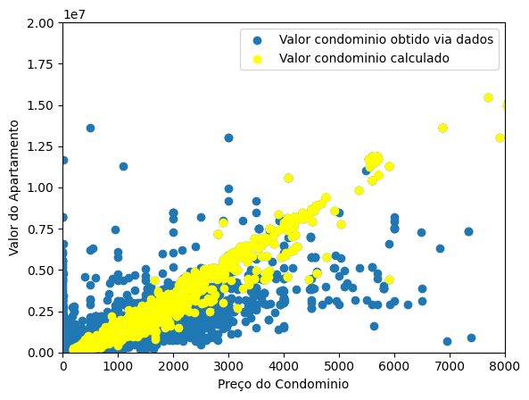

```python
plt.scatter(x=df_limpo["Valor_condominio"],y=df_limpo["Preco"], label = "Valor condominio obtido via dados")
plt.scatter(x=df_limpo["Valor_condominio"][NA_condominio],y=df_limpo["Preco"][NA_condominio], c="yellow", label = "Valor condominio calculado")
plt.legend(loc="upper right")
plt.xlim(0,8000)
plt.ylim(0,20000000)
plt.xlabel("Preço do Condominio")
plt.ylabel("Valor do Apartamento")
```

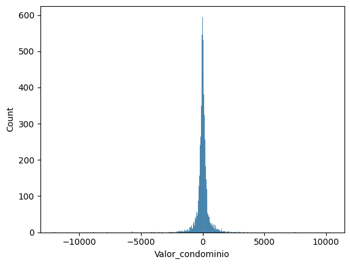

```python
residuos = modelo.predict(data[["Area_privativa","Preco","IPTU"]]) - data["Valor_condominio"]
sns.histplot(residuos)
```

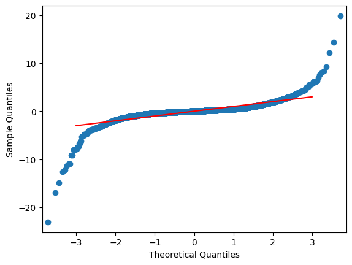

```python
qplot = sm.qqplot(scale(residuos))
plt.plot([3, -3],[3,-3], 'r-')
```

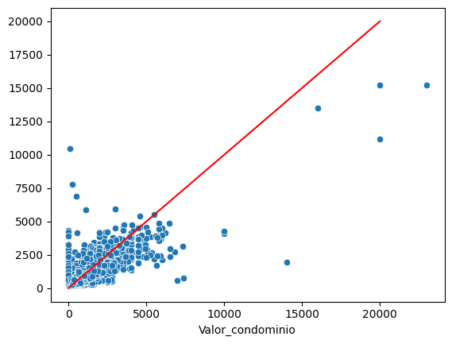

```python
sns.scatterplot(y= modelo.predict(data[["Area_privativa","Preco","IPTU"]]),x =data["Valor_condominio"])
plt.plot([20000, 0],[20000,0], 'r-')
plt.show()
```

```python
stats.shapiro(residuos)
```

```
ShapiroResult(statistic=0.6706581711769104, pvalue=0.0)
```

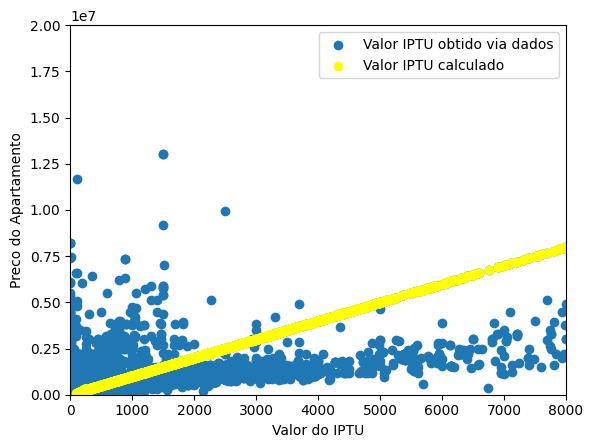

```python
plt.scatter(x=df_limpo["IPTU"],y=df_limpo["Preco"], label = "Valor IPTU obtido via dados")
plt.scatter(x=df_limpo.query("IPTU == Media_iptu")["IPTU"],y=df_limpo.query("IPTU == Media_iptu")["Preco"], c="yellow", label = "Valor IPTU calculado")
plt.legend(loc="upper right")
plt.xlim(0,8000)
plt.ylim(0,20000000)
plt.xlabel("Valor do IPTU")
plt.ylabel("Preco do Apartamento")
```

Abaixo esta sendo separado os dados de preço por metro quadrado de acordo com cada bairro para ser realizada a analise de Kruskal Wallis

```python
valores_por_bairro = []
bairros = []

for dados in df_limpo.groupby("Bairro"):
    if len(dados[1]["Valor_por_metro_quadrado"].values) > 10:
        bairros.append(dados[0])
        valores_por_bairro.append(dados[1]["Valor_por_metro_quadrado"].values)

resultado = stats.kruskal(*valores_por_bairro)
resultado
```

```
KruskalResult(statistic=3649.8274737471716, pvalue=0.0)
```

Aqui esta sendo verificado se esses dados seguem uma distribuição normal

```python
normalidade = []

for i in range(len(valores_por_bairro)):
    normalidade.append(stats.shapiro(valores_por_bairro[i]).pvalue)

pd.Series(normalidade)[1:10]
```

```
1    1.779199e-05
2    4.162110e-03
3    7.972562e-04
4    8.217690e-05
5    2.603210e-14
6    1.479794e-01
7    0.000000e+00
8    0.000000e+00
9    5.094159e-03
dtype: float64
```

Como grande parte dos dados são rejeitados de seguir uma distribuição normal, prosseguiu-se com teste de Wilcoxon Rank Sum

```python
testes = []
par_1 = []
par_2 = []

for i in range(len(valores_por_bairro)):
    for j in range(i + 1, len(valores_por_bairro)):
        par_1.append(bairros[i])
        par_2.append(bairros[j])
        testes.append(stats.ranksums(valores_por_bairro[i],valores_por_bairro[j]).pvalue)
```

Foi então realizada a correção de Holm para reduzir os erros do Tipo 1, quando se rejeita uma hipotese nula, mas na verdade ela é verdadeira.

```python
p_valor_corrigido = sm.stats.multipletests(testes, method='holm')
```

```python
pares_valores = pd.DataFrame({"Bairro_1": par_1, "Bairro_2": par_2, "P_valor":list(p_valor_corrigido[1])})
pares_valores.query("P_valor > 0.05 & (Bairro_1 == 'Batel' | Bairro_2 == 'Batel')")
```

|  | Bairro_1 | Bairro_2 | P_valor |
| --- | --- | --- | --- |
| 350 | Batel | Bigorrilho | 1.000000 |
| 352 | Batel | Bom Retiro | 1.000000 |
| 356 | Batel | Campina do Siqueira | 0.436747 |
| 367 | Batel | Guabirotuba | 0.217288 |
| 370 | Batel | Hugo Lange | 1.000000 |
| 380 | Batel | Prado Velho | 0.214280 |
| 385 | Batel | Santo Inácio | 0.980297 |
| 386 | Batel | Seminário | 1.000000 |

O mesmo processo foi seguido para a analise das areas provativas separadas por bairro

```python
areas_por_bairro = []
bairros = []

for dados in df_limpo.groupby("Bairro"):
    if len(dados[1]["Area_privativa"].values) > 10:
        bairros.append(dados[0])
        areas_por_bairro.append(dados[1]["Area_privativa"].values)

resultado = stats.kruskal(*areas_por_bairro)
print(resultado)

normalidade = []

for i in range(len(areas_por_bairro)):
    normalidade.append(stats.shapiro(areas_por_bairro[i]).pvalue)

print(normalidade)

testes = []
par_1 = []
par_2 = []

for i in range(len(areas_por_bairro)):
    for j in range(i + 1, len(areas_por_bairro)):
        par_1.append(bairros[i])
        par_2.append(bairros[j])
        testes.append(stats.ranksums(areas_por_bairro[i],areas_por_bairro[j]).pvalue)

p_valor_corrigido = sm.stats.multipletests(testes, method='holm')

pares_areas = pd.DataFrame({"Bairro_1": par_1, "Bairro_2": par_2, "P_valor":list(p_valor_corrigido[1])})
```

[output not shown]

```python
grafico_medias = medias_bairros.loc[bairros].reset_index()
```

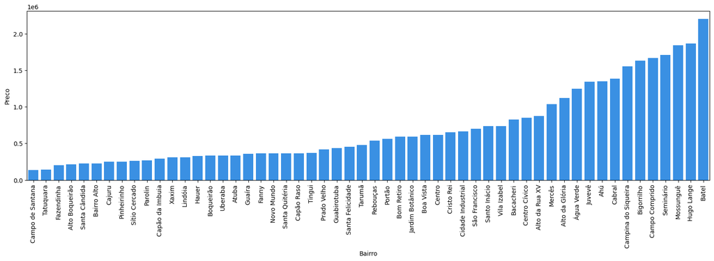

```python
plt.figure(figsize=(20,5))
sns.barplot(data=grafico_medias.sort_values("Preco"),x="Bairro",y="Preco", color="dodgerblue")
plt.xticks(rotation=90)
plt.show()
```

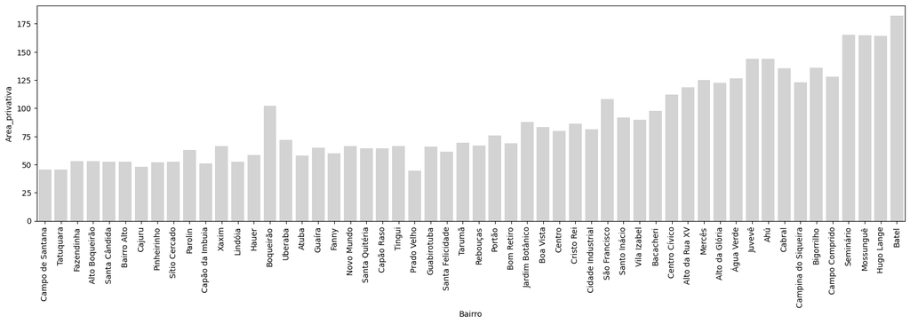

```python
plt.figure(figsize=(20,5))
sns.barplot(data=grafico_medias.sort_values("Preco"),x="Bairro",y="Area_privativa", color="lightgrey")
plt.xticks(rotation=90)
plt.show()
```

```python
bairro_interesse = 'Batel'
display(pares_valores[((pares_valores["Bairro_1"] == bairro_interesse) | (pares_valores["Bairro_2"] == bairro_interesse)) & (pares_valores["P_valor"] > 0.05)])
display(pares_areas[((pares_areas["Bairro_1"] == bairro_interesse) | (pares_areas["Bairro_2"] == bairro_interesse)) & (pares_areas["P_valor"] > 0.05)])
```

|  | Bairro_1 | Bairro_2 | P_valor |
| --- | --- | --- | --- |
| 350 | Batel | Bigorrilho | 1.000000 |
| 352 | Batel | Bom Retiro | 1.000000 |
| 356 | Batel | Campina do Siqueira | 0.436747 |
| 367 | Batel | Guabirotuba | 0.217288 |
| 370 | Batel | Hugo Lange | 1.000000 |
| 380 | Batel | Prado Velho | 0.214280 |
| 385 | Batel | Santo Inácio | 0.980297 |
| 386 | Batel | Seminário | 1.000000 |

|  | Bairro_1 | Bairro_2 | P_valor |
| --- | --- | --- | --- |
| 370 | Batel | Hugo Lange | 1.0 |
| 375 | Batel | Mossunguê | 1.0 |
| 386 | Batel | Seminário | 1.0 |

```python
area = []
valor = []

for bairro_interesse in bairros:

    valor.append(pares_valores[((pares_valores["Bairro_1"] == bairro_interesse) | (pares_valores["Bairro_2"] == bairro_interesse)) & (pares_valores["P_valor"] > 0.05)].shape[0])
    area.append(pares_areas[((pares_areas["Bairro_1"] == bairro_interesse) | (pares_areas["Bairro_2"] == bairro_interesse)) & (pares_areas["P_valor"] > 0.05)].shape[0])

pd.DataFrame(zip(bairros,area,valor), columns=["Bairro","area","valor"])
```

|  | Bairro | area | valor |
| --- | --- | --- | --- |
| 0 | Ahú | 8 | 15 |
| 1 | Alto Boqueirão | 23 | 7 |
| 2 | Alto da Glória | 16 | 25 |
| 3 | Alto da Rua XV | 16 | 28 |
| 4 | Atuba | 29 | 25 |
| 5 | Bacacheri | 11 | 19 |
| 6 | Bairro Alto | 31 | 19 |
| 7 | Batel | 3 | 8 |
| 8 | Bigorrilho | 12 | 6 |
| 9 | Boa Vista | 17 | 21 |
| 10 | Bom Retiro | 43 | 27 |
| 11 | Boqueirão | 29 | 19 |
| 12 | Cabral | 8 | 15 |
| 13 | Cajuru | 22 | 20 |
| 14 | Campina do Siqueira | 17 | 26 |
| 15 | Campo Comprido | 14 | 25 |
| 16 | Campo de Santana | 16 | 2 |
| 17 | Capão Raso | 20 | 16 |
| 18 | Capão da Imbuia | 25 | 30 |
| 19 | Centro | 33 | 23 |
| 20 | Centro Cívico | 20 | 37 |
| 21 | Cidade Industrial | 24 | 27 |
| 22 | Cristo Rei | 12 | 18 |
| 23 | Fanny | 36 | 33 |
| 24 | Fazendinha | 23 | 5 |
| 25 | Guabirotuba | 46 | 45 |
| 26 | Guaíra | 28 | 25 |
| 27 | Hauer | 32 | 30 |
| 28 | Hugo Lange | 12 | 19 |
| 29 | Jardim Botânico | 21 | 23 |
| 30 | Juvevê | 10 | 15 |
| 31 | Lindóia | 30 | 26 |
| 32 | Mercês | 12 | 28 |
| 33 | Mossunguê | 5 | 13 |
| 34 | Novo Mundo | 20 | 17 |
| 35 | Parolin | 38 | 22 |
| 36 | Pinheirinho | 19 | 13 |
| 37 | Portão | 22 | 18 |
| 38 | Prado Velho | 4 | 29 |
| 39 | Rebouças | 26 | 19 |
| 40 | Santa Cândida | 20 | 6 |
| 41 | Santa Felicidade | 31 | 28 |
| 42 | Santa Quitéria | 25 | 22 |
| 43 | Santo Inácio | 28 | 29 |
| 44 | Seminário | 11 | 12 |
| 45 | São Francisco | 29 | 30 |
| 46 | Sítio Cercado | 23 | 6 |
| 47 | Tarumã | 33 | 27 |
| 48 | Tatuquara | 15 | 3 |
| 49 | Tingui | 22 | 15 |
| 50 | Uberaba | 31 | 16 |
| 51 | Vila Izabel | 14 | 17 |
| 52 | Xaxim | 22 | 15 |
| 53 | Água Verde | 11 | 12 |